# Dimensionality Reduction & Feature Selection

Geoffrey Chege

2022-06-10

# 1. Introduction

## 1.1 Defining the question

- I am a Data analyst at Carrefour Kenya and I am currently undertaking a project that will inform the marketing department on the most relevant marketing strategies that will result in the highest no. of sales (total price including tax).

## 1.2 Metric for success

- Be able to reduce the dataset to a low dimensional dataset using the t-SNE algorithm or PCA.

## 1.3 Understanding the context

- Carrefour operates different store formats, as well as multiple online offerings to meet the growing needs of its diversified customer base.
- In line with the brand’s commitment to provide the widest range of quality products and value for money, Carrefour offers an unrivalled choice of more than 500,000 food and non-food products, and a locally inspired exemplary customer experience to create great moments for everyone every day.

## 1.5 Data Relevance

- Link to the dataset: http://bit.ly/SupermarketDatasetII

# 2. Loading the necessary libraries and the dataset.

```r
library(ggplot2)
library(Rtsne)
library(e1071)
library(lattice)
library(corrplot)
library(caret)
library(superml)
library(CatEncoders)
library(FSelector)

library(tidyr)
library(magrittr)
library(warn = -1)
library(RColorBrewer)

library(DataExplorer)
library(Hmisc)
library(pastecs)
library(psych)
library(factoextra)
library(dplyr)
library(ggcorrplot)
library(clustvarsel)
library(mclust)
library("cluster")
```

```r
df <- read.csv("C:/Users/user/Downloads/Supermarket_Dataset_1 - Sales Data.csv")
head(df)
```

```
##    Invoice.ID Branch Customer.type Gender           Product.line Unit.price
## 1 750-67-8428      A        Member Female      Health and beauty      74.69
## 2 226-31-3081      C        Normal Female Electronic accessories      15.28
## 3 631-41-3108      A        Normal   Male     Home and lifestyle      46.33
## 4 123-19-1176      A        Member   Male      Health and beauty      58.22
## 5 373-73-7910      A        Normal   Male      Sports and travel      86.31
## 6 699-14-3026      C        Normal   Male Electronic accessories      85.39
##   Quantity     Tax      Date  Time     Payment   cogs gross.margin.percentage
## 1        7 26.1415  1/5/2019 13:08     Ewallet 522.83                4.761905
## 2        5  3.8200  3/8/2019 10:29        Cash  76.40                4.761905
## 3        7 16.2155  3/3/2019 13:23 Credit card 324.31                4.761905
## 4        8 23.2880 1/27/2019 20:33     Ewallet 465.76                4.761905
## 5        7 30.2085  2/8/2019 10:37     Ewallet 604.17                4.761905
## 6        7 29.8865 3/25/2019 18:30     Ewallet 597.73                4.761905
##   gross.income Rating    Total
## 1      26.1415    9.1 548.9715
## 2       3.8200    9.6  80.2200
## 3      16.2155    7.4 340.5255
## 4      23.2880    8.4 489.0480
## 5      30.2085    5.3 634.3785
## 6      29.8865    4.1 627.6165
```

# 3. Data Cleaning.

## Checking the structure of the data.

```r
str(df)
```

```
## 'data.frame':    1000 obs. of  16 variables:
##  $ Invoice.ID             : chr  "750-67-8428" "226-31-3081" "631-41-3108" "123-19-1176" ...
##  $ Branch                 : chr  "A" "C" "A" "A" ...
##  $ Customer.type          : chr  "Member" "Normal" "Normal" "Member" ...
##  $ Gender                 : chr  "Female" "Female" "Male" "Male" ...
##  $ Product.line           : chr  "Health and beauty" "Electronic accessories" "Home and lifestyle" "Health and beauty" ...
##  $ Unit.price             : num  74.7 15.3 46.3 58.2 86.3 ...
##  $ Quantity               : int  7 5 7 8 7 7 6 10 2 3 ...
##  $ Tax                    : num  26.14 3.82 16.22 23.29 30.21 ...
##  $ Date                   : chr  "1/5/2019" "3/8/2019" "3/3/2019" "1/27/2019" ...
##  $ Time                   : chr  "13:08" "10:29" "13:23" "20:33" ...
##  $ Payment                : chr  "Ewallet" "Cash" "Credit card" "Ewallet" ...
##  $ cogs                   : num  522.8 76.4 324.3 465.8 604.2 ...
##  $ gross.margin.percentage: num  4.76 4.76 4.76 4.76 4.76 ...
##  $ gross.income           : num  26.14 3.82 16.22 23.29 30.21 ...
##  $ Rating                 : num  9.1 9.6 7.4 8.4 5.3 4.1 5.8 8 7.2 5.9 ...
##  $ Total                  : num  549 80.2 340.5 489 634.4 ...
```

- For the analysis, I will need to convert the character columns into factors.

## Data Cleaning:

```r
df$Invoice.ID <- as.factor(df$Invoice.ID)
df$Branch <- as.factor(df$Branch)
df$Customer.type <- as.factor(df$Customer.type)
df$Gender <- as.factor(df$Gender)
df$Product.line <- as.factor(df$Product.line)
df$Payment <- as.factor(df$Payment)
df$Date <- as.Date(df$Date, format = "%m/%d/%y")

str(df) #confirming the changes
```

```
## 'data.frame':    1000 obs. of  16 variables:
##  $ Invoice.ID             : Factor w/ 1000 levels "101-17-6199",..: 815 143 654 19 340 734 316 265 703 727 ...
##  $ Branch                 : Factor w/ 3 levels "A","B","C": 1 3 1 1 1 3 1 3 1 2 ...
##  $ Customer.type          : Factor w/ 2 levels "Member","Normal": 1 2 2 1 2 2 1 2 1 1 ...
##  $ Gender                 : Factor w/ 2 levels "Female","Male": 1 1 2 2 2 2 1 1 1 1 ...
##  $ Product.line           : Factor w/ 6 levels "Electronic accessories",..: 4 1 5 4 6 1 1 5 4 3 ...
##  $ Unit.price             : num  74.7 15.3 46.3 58.2 86.3 ...
##  $ Quantity               : int  7 5 7 8 7 7 6 10 2 3 ...
##  $ Tax                    : num  26.14 3.82 16.22 23.29 30.21 ...
##  $ Date                   : Date, format: "2020-01-05" "2020-03-08" ...
##  $ Time                   : chr  "13:08" "10:29" "13:23" "20:33" ...
##  $ Payment                : Factor w/ 3 levels "Cash","Credit card",..: 3 1 2 3 3 3 3 3 2 2 ...
##  $ cogs                   : num  522.8 76.4 324.3 465.8 604.2 ...
##  $ gross.margin.percentage: num  4.76 4.76 4.76 4.76 4.76 ...
##  $ gross.income           : num  26.14 3.82 16.22 23.29 30.21 ...
##  $ Rating                 : num  9.1 9.6 7.4 8.4 5.3 4.1 5.8 8 7.2 5.9 ...
##  $ Total                  : num  549 80.2 340.5 489 634.4 ...
```

- Next, I will check for duplicates:

```r
# checking for duplicates
df[duplicated(df), ]
```

```
##  [1] Invoice.ID              Branch                  Customer.type
##  [4] Gender                  Product.line            Unit.price
##  [7] Quantity                Tax                     Date
## [10] Time                    Payment                 cogs
## [13] gross.margin.percentage gross.income            Rating
## [16] Total
## <0 rows> (or 0-length row.names)
```

- There are no duplicates in the dataset.
- Checking for mssing values:

```r
# checking for missing values
colSums(is.na(df))
```

```
##              Invoice.ID                  Branch           Customer.type
##                       0                       0                       0
##                  Gender            Product.line              Unit.price
##                       0                       0                       0
##                Quantity                     Tax                    Date
##                       0                       0                       0
##                    Time                 Payment                    cogs
##                       0                       0                       0
## gross.margin.percentage            gross.income                  Rating
##                       0                       0                       0
##                   Total
##                       0
```

- There are no missing values in the dataset.

### Outliers

- I will use box plots to check for outliers.

#### Boxplot for “unit.price” column

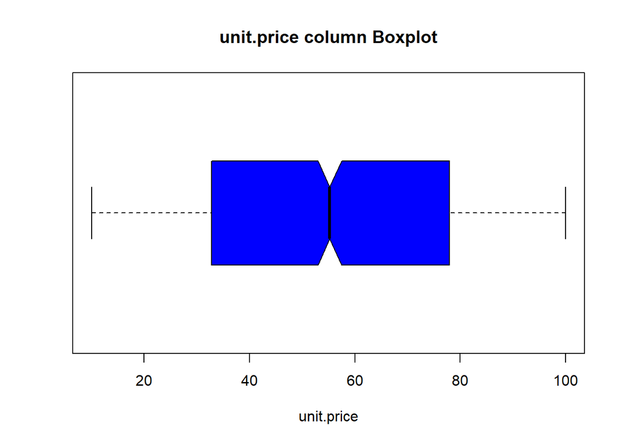

- There are no outliers in the “unit.price” column.

#### Boxplot for “Tax” column

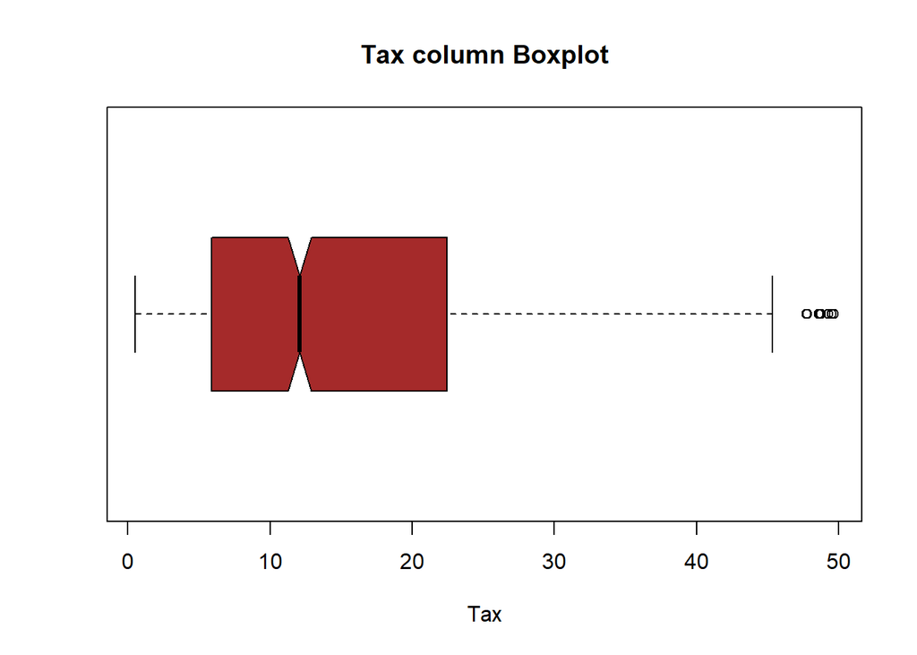

- There are outliers in the “Tax” column. I will keep them in my analysis because they represent true values in the data.

#### Boxplot for “Cogs” column

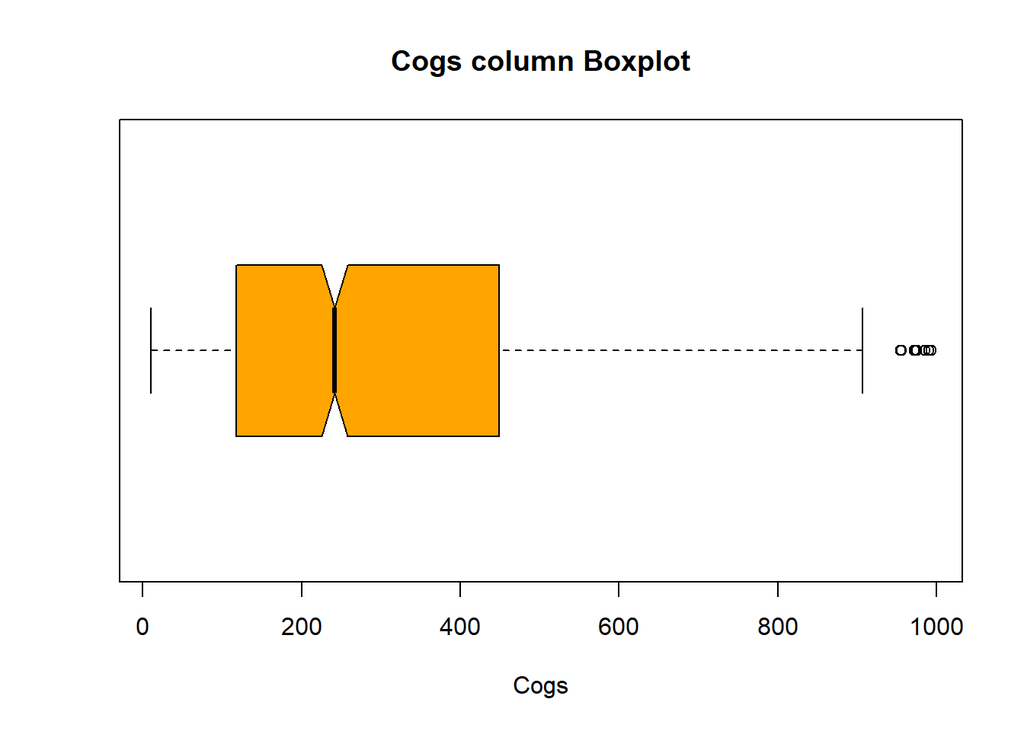

- There are outliers in the “Cogs” column. I will keep them in my analysis because they represent true values in the data.

#### Boxplot for “gross.margin.percentage” column

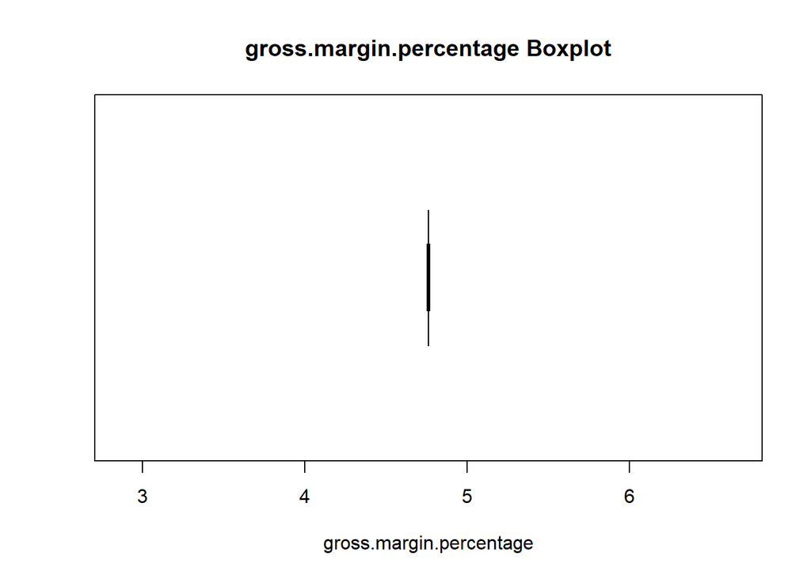

#### Boxplot for “gross.income” column

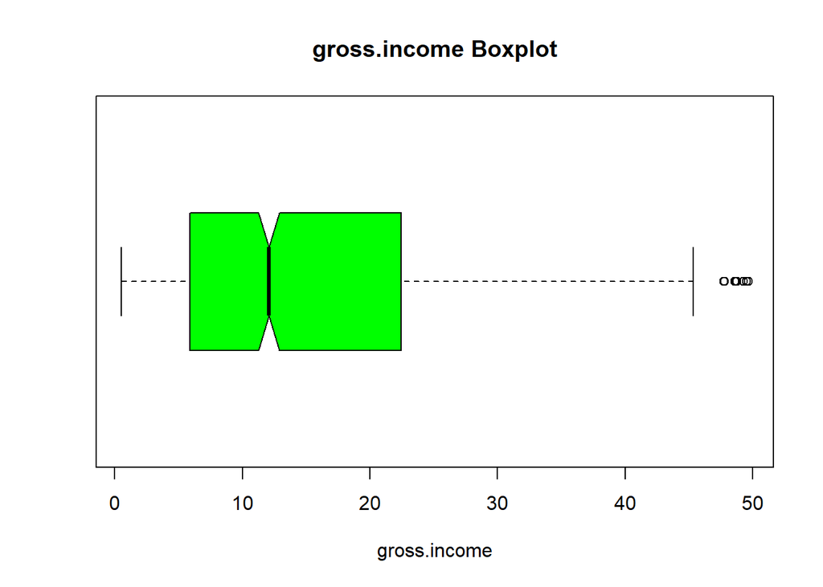

- There are outliers in the “gross.income” column. I will keep them in my analysis because they represent true values in the data.

#### Boxplot for “Rating” column

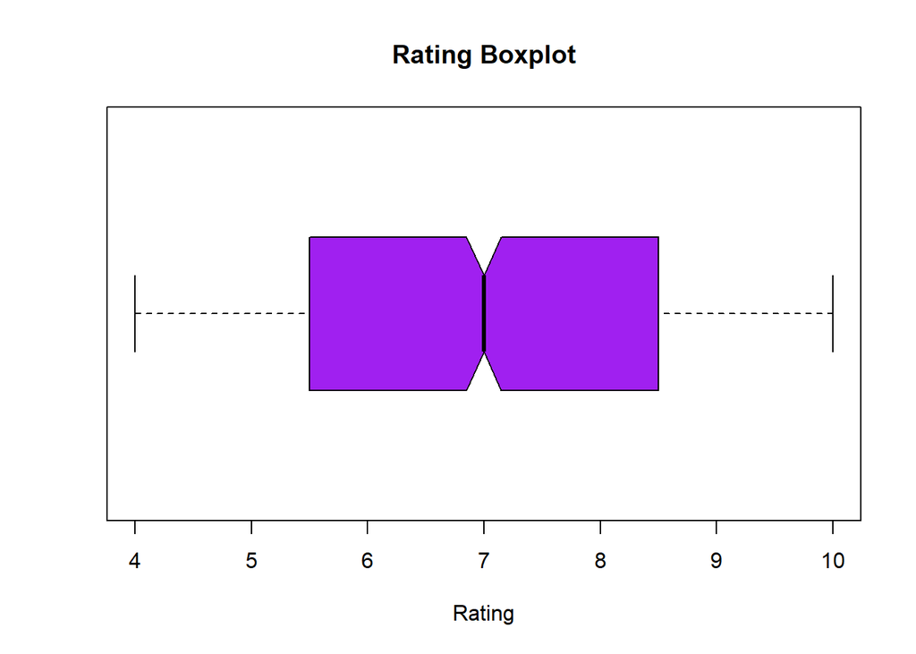

- There are no outliers in the “Rating” column.

#### Boxplot for “Total” column

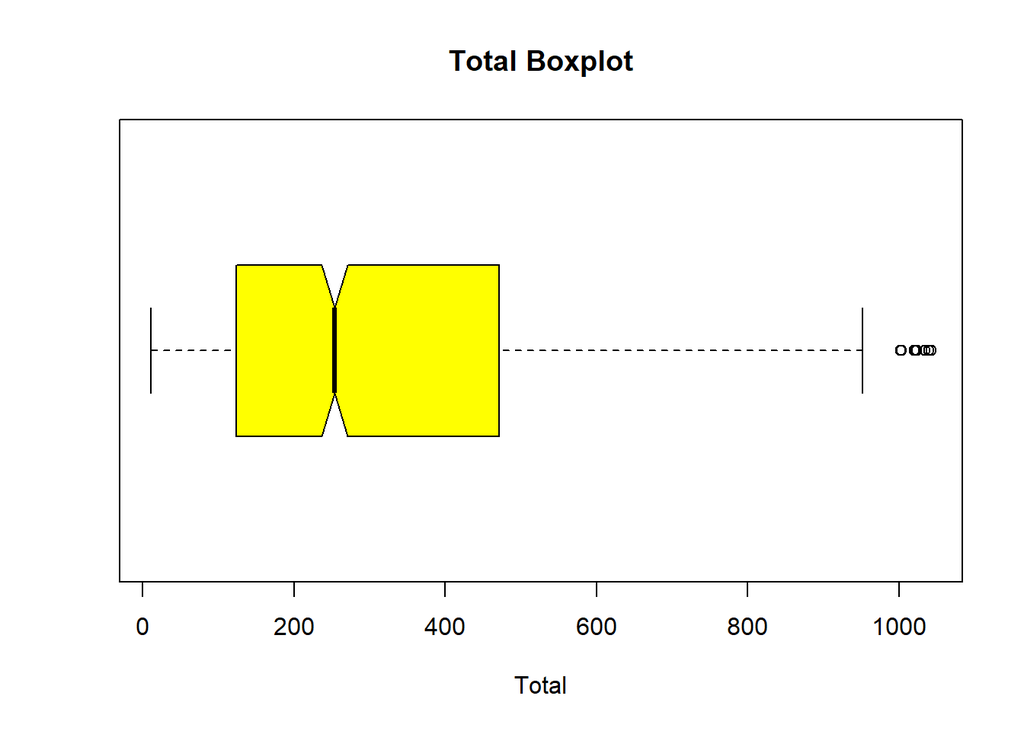

- There are outliers in the “Total” column. I will keep them in my analysis because they represent true values in the data.

# 4. Exploaratory Data Analysis.

## 4.1 Univariate Analysis.

### Distributions

#### Histograms:

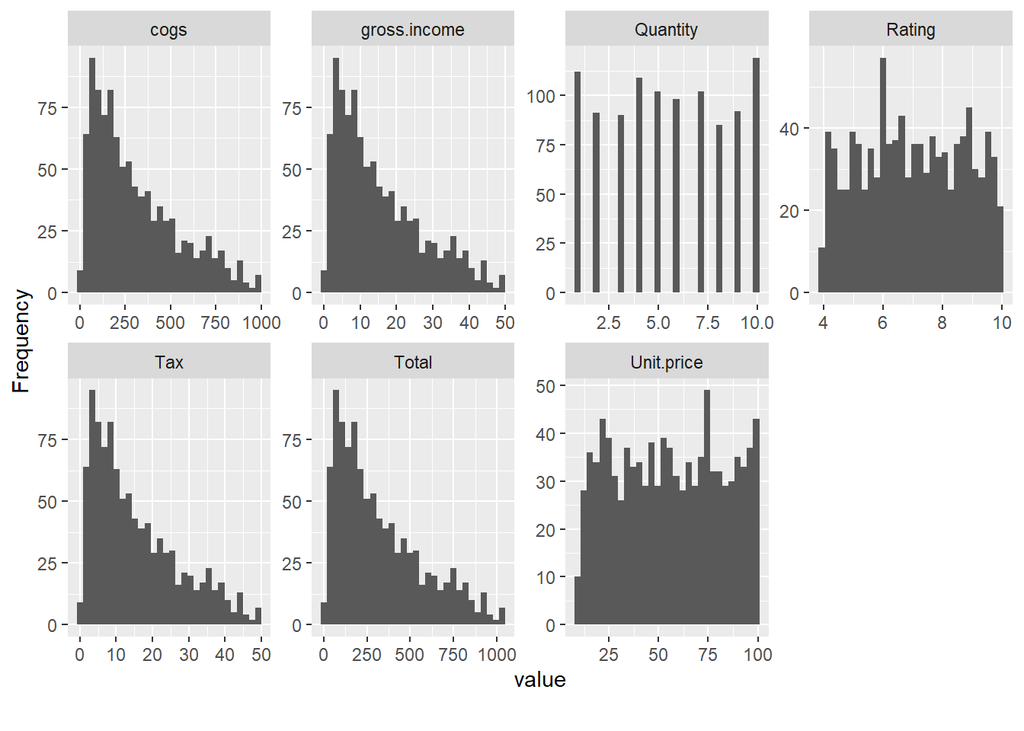

```r
plot_histogram(df)
```

- From the histograms, we get the following insights:
  - Cogs, gross.income, Tax and Total columns are positively skewed, meaning we expect the mean will be greater than the median.
  - Unit.price and Rating columns have fairly even distribution.

#### Bar Plots:

```
## 3 columns ignored with more than 50 categories.
## Invoice.ID: 1000 categories
## Date: 89 categories
## Time: 506 categories
```

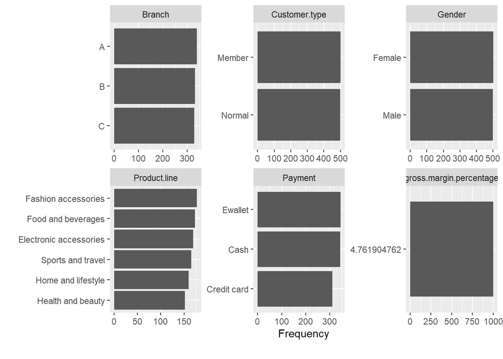

```r
plot_bar(df)
```

- From the bar plots, we observe that Branch, Customer.type, Gender, Product.line and Payment columns have an even distribution.

### Description and Summary of Data:

- Description:

```r
describe(df)
```

```
##                         vars    n   mean     sd median trimmed    mad   min
## Invoice.ID*                1 1000 500.50 288.82 500.50  500.50 370.65  1.00
## Branch*                    2 1000   1.99   0.82   2.00    1.99   1.48  1.00
## Customer.type*             3 1000   1.50   0.50   1.00    1.50   0.00  1.00
## Gender*                    4 1000   1.50   0.50   1.00    1.50   0.00  1.00
## Product.line*              5 1000   3.45   1.72   3.00    3.44   1.48  1.00
## Unit.price                 6 1000  55.67  26.49  55.23   55.62  33.37 10.08
## Quantity                   7 1000   5.51   2.92   5.00    5.51   2.97  1.00
## Tax                        8 1000  15.38  11.71  12.09   14.00  11.13  0.51
## Date                       9 1000    NaN     NA     NA     NaN     NA   Inf
## Time*                     10 1000 252.18 147.07 249.00  252.49 190.51  1.00
## Payment*                  11 1000   2.00   0.83   2.00    2.00   1.48  1.00
## cogs                      12 1000 307.59 234.18 241.76  279.91 222.65 10.17
## gross.margin.percentage   13 1000   4.76   0.00   4.76    4.76   0.00  4.76
## gross.income              14 1000  15.38  11.71  12.09   14.00  11.13  0.51
## Rating                    15 1000   6.97   1.72   7.00    6.97   2.22  4.00
## Total                     16 1000 322.97 245.89 253.85  293.91 233.78 10.68
##                             max   range skew kurtosis   se
## Invoice.ID*             1000.00  999.00 0.00    -1.20 9.13
## Branch*                    3.00    2.00 0.02    -1.51 0.03
## Customer.type*             2.00    1.00 0.00    -2.00 0.02
## Gender*                    2.00    1.00 0.00    -2.00 0.02
## Product.line*              6.00    5.00 0.06    -1.28 0.05
## Unit.price                99.96   89.88 0.01    -1.22 0.84
## Quantity                  10.00    9.00 0.01    -1.22 0.09
## Tax                       49.65   49.14 0.89    -0.09 0.37
## Date                       -Inf    -Inf   NA       NA   NA
## Time*                    506.00  505.00 0.00    -1.25 4.65
## Payment*                   3.00    2.00 0.00    -1.55 0.03
## cogs                     993.00  982.83 0.89    -0.09 7.41
## gross.margin.percentage    4.76    0.00  NaN      NaN 0.00
## gross.income              49.65   49.14 0.89    -0.09 0.37
## Rating                    10.00    6.00 0.01    -1.16 0.05
## Total                   1042.65 1031.97 0.89    -0.09 7.78
```

- Summary:

```r
summary(df)
```

```
##        Invoice.ID  Branch  Customer.type    Gender
##  101-17-6199:  1   A:340   Member:501    Female:501
##  101-81-4070:  1   B:332   Normal:499    Male  :499
##  102-06-2002:  1   C:328
##  102-77-2261:  1
##  105-10-6182:  1
##  105-31-1824:  1
##  (Other)    :994
##                  Product.line   Unit.price       Quantity          Tax
##  Electronic accessories:170   Min.   :10.08   Min.   : 1.00   Min.   : 0.5085
##  Fashion accessories   :178   1st Qu.:32.88   1st Qu.: 3.00   1st Qu.: 5.9249
##  Food and beverages    :174   Median :55.23   Median : 5.00   Median :12.0880
##  Health and beauty     :152   Mean   :55.67   Mean   : 5.51   Mean   :15.3794
##  Home and lifestyle    :160   3rd Qu.:77.94   3rd Qu.: 8.00   3rd Qu.:22.4453
##  Sports and travel     :166   Max.   :99.96   Max.   :10.00   Max.   :49.6500
##
##       Date                Time                  Payment         cogs
##  Min.   :2020-01-01   Length:1000        Cash       :344   Min.   : 10.17
##  1st Qu.:2020-01-24   Class :character   Credit card:311   1st Qu.:118.50
##  Median :2020-02-13   Mode  :character   Ewallet    :345   Median :241.76
##  Mean   :2020-02-14                                        Mean   :307.59
##  3rd Qu.:2020-03-08                                        3rd Qu.:448.90
##  Max.   :2020-03-30                                        Max.   :993.00
##
##  gross.margin.percentage  gross.income         Rating           Total
##  Min.   :4.762           Min.   : 0.5085   Min.   : 4.000   Min.   :  10.68
##  1st Qu.:4.762           1st Qu.: 5.9249   1st Qu.: 5.500   1st Qu.: 124.42
##  Median :4.762           Median :12.0880   Median : 7.000   Median : 253.85
##  Mean   :4.762           Mean   :15.3794   Mean   : 6.973   Mean   : 322.97
##  3rd Qu.:4.762           3rd Qu.:22.4453   3rd Qu.: 8.500   3rd Qu.: 471.35
##  Max.   :4.762           Max.   :49.6500   Max.   :10.000   Max.   :1042.65
##
```

### A function to get the mode

```r
# a function for code
mode <- function(x){
  uniqx <- unique(x)
  uniqx[which.max(tabulate(match(x, uniqx)))]
}
```

#### Unit.price Column

- From the summary and description, we can gather the following about the Unit.price column:
  - Mean: 55.67
  - Median: 55.23
  - Skewness: 0.01
  - Kurtosis: -1.22
- The mode is:

```r
mode(df$Unit.price)
```

```
## [1] 83.77
```

#### Quantity Column

- From the summary and description, we can gather the following about the Quantity column:
  - Mean: 5.51
  - Median: 5.00
  - Skewness: 0.01
  - Kurtosis: -1.22
- The mode is:

```r
mode(df$Quantity)
```

```
## [1] 10
```

#### Tax Column

- From the summary and description, we can gather the following about the Tax column:
  - Mean: 15.3794
  - Median: 12.0880
  - Skewness: 0.89
  - Kurtosis: -0.09
- The mode is:

```r
mode(df$Tax)
```

```
## [1] 39.48
```

#### Cogs column

- From the summary and description, we can gather the following about the Cogs column:
  - Mean: 307.59
  - Median: 241.76
  - Skewness: 0.89
  - Kurtosis: -0.09
- The mode is:

```r
mode(df$cogs)
```

```
## [1] 789.6
```

#### gross.income column

- From the summary and description, we can gather the following about the gross.income column:
  - Mean: 15.3794
  - Median: 12.0880
  - Skewness: 0.89
  - Kurtosis: -0.09
- The mode is:

```r
mode(df$gross.income)
```

```
## [1] 39.48
```

#### Rating column

- From the summary and description, we can gather the following about the Rating column:
  - Mean: 6.973
  - Median: 7.000
  - Skewness: 0.01
  - Kurtosis: -1.16
- The mode is:

```r
mode(df$Rating)
```

```
## [1] 6
```

#### Total column

- From the summary and description, we can gather the following about the Total column:
  - Mean: 322.97
  - Median: 253.85
  - Skewness: 0.89
  - Kurtosis: -0.09
- The mode is:

```r
mode(df$Total)
```

```
## [1] 829.08
```

## 4.2 Bivariate Analysis

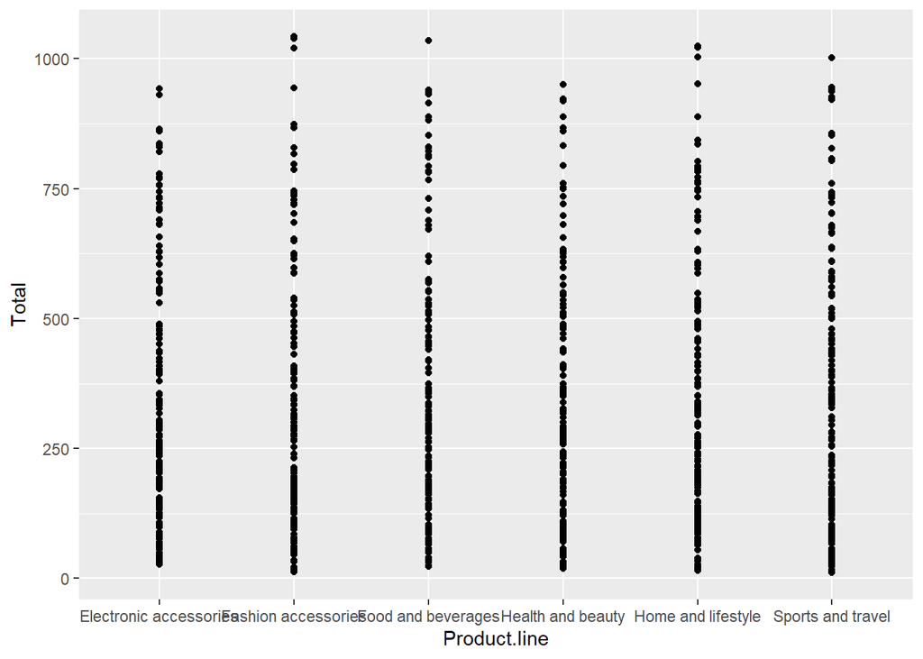

```r
ggplot(df, aes(x=Product.line, y=Total)) +
  geom_point()
```

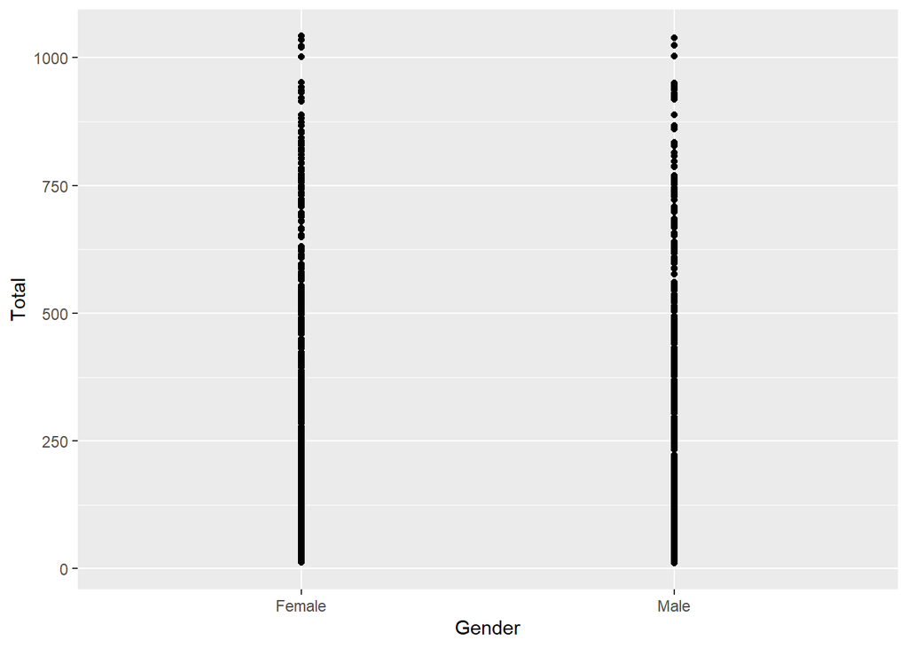

```r
ggplot(df ,aes(Gender, Total)) +
  geom_point()
```

- Total Price is equally distributed in terms of gender

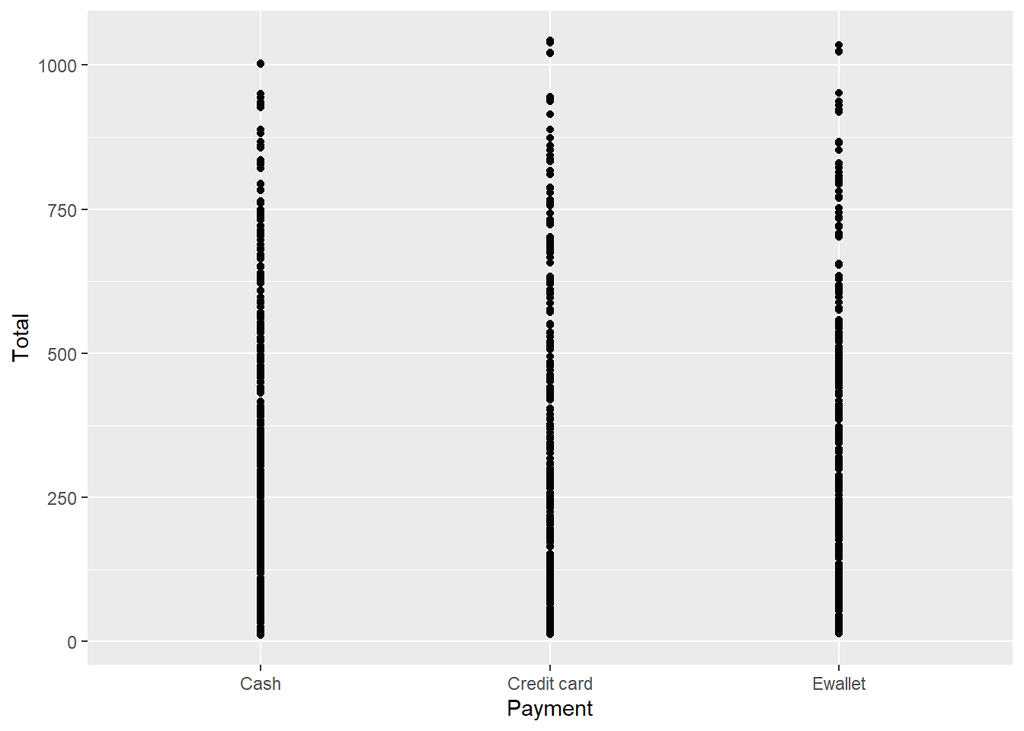

```r
ggplot(df, aes(Payment, Total)) +
  geom_point()
```

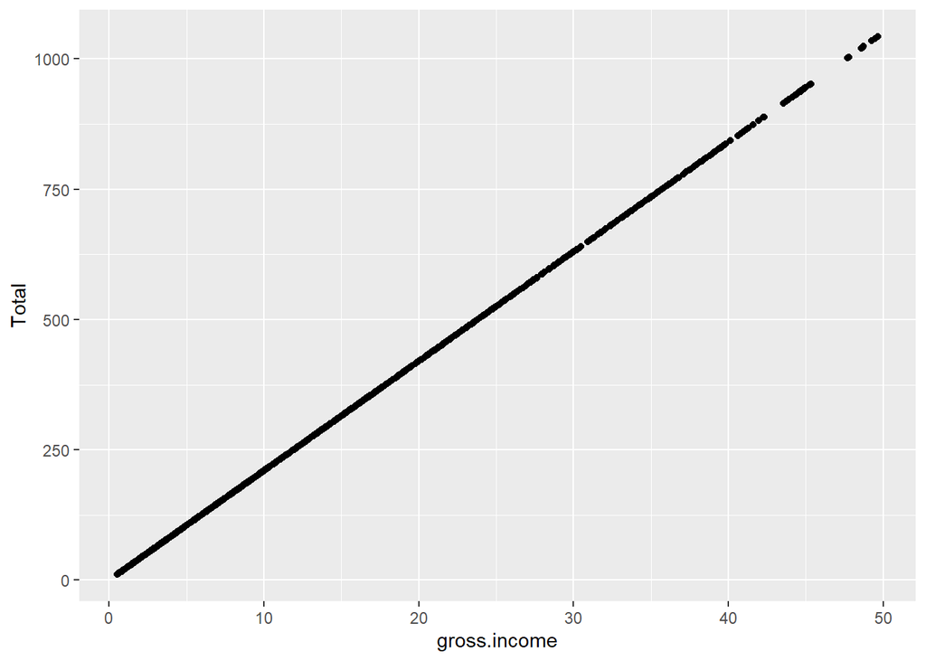

```r
ggplot(df, aes(gross.income, Total)) +
  geom_point()
```

- There is a positive linear relationship between the total at checkout and the consumers gross income.

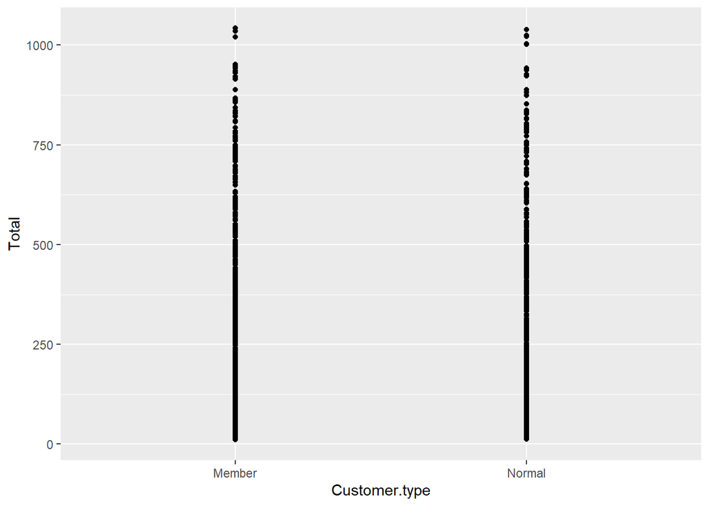

```r
ggplot(df, aes(Customer.type , Total)) +
  geom_point()
```

- Members and non members have a nearly equal distribution in expenditure with Members having no breaks in prices.

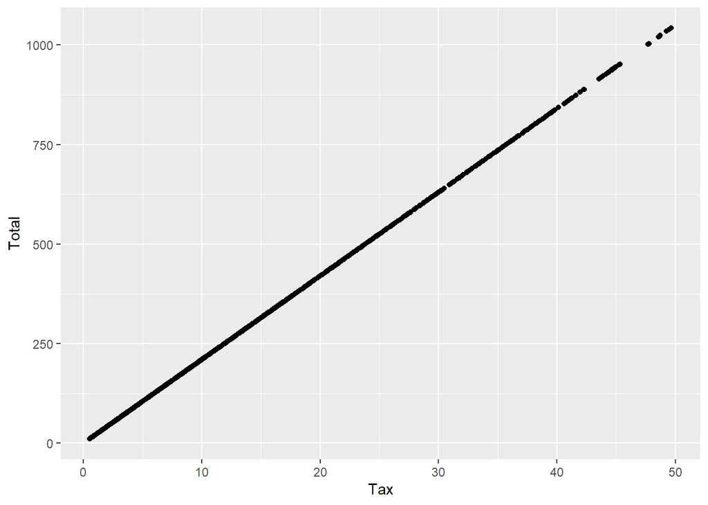

```r
ggplot(df, aes(Tax, Total)) +
  geom_point()
```

- There is a positive linear relationship between tax and total price. As expected, the higher the tax on items, the more they cost.

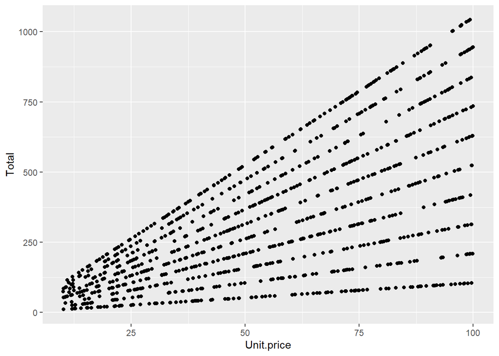

```r
ggplot(df, aes(Unit.price, Total)) +
  geom_point()
```

- There are several positive linear relationships with the Unit Price variable: the higher it is the higher the total price is.

### Heatmap

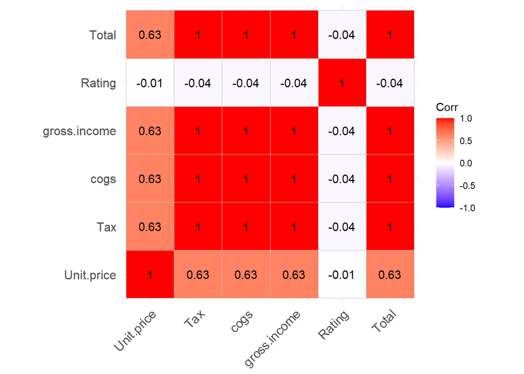

```r
# Heat map
# Checking the relationship between the variables


# Using Numeric variables only
numeric_tbl <- df %>%
  select_if(is.numeric) %>%
  select(Unit.price, Tax, cogs, gross.income, Rating, Total)

# Calculate the correlations
corr <- cor(numeric_tbl, use = "complete.obs")
ggcorrplot(round(corr, 2),
           type = "full", lab = T)
```

# 5. Part 1: Dimensionality Reduction

```r
# Label Encoding branch column and storing in a copy
branch <- LabelEncoder.fit(df$Branch)
df$Branch <- transform(branch, factor(df$Branch))

# Label Encoding Gender column and storing in a copy
gender <- LabelEncoder.fit(df$Gender)
df$Gender <- transform(gender, factor(df$Gender))

# Label Encoding Customer.type column and storing in a copy
customer <- LabelEncoder.fit(df$Customer.type)
df$Customer.type <- transform(customer, factor(df$Customer.type))

# Label Encoding product.line column and storing in a copy
product <- LabelEncoder.fit(df$Product.line)
df$Product.line <- transform(product, factor(df$Product.line))

# Label Encoding payment column and storing in a copy
pay <- LabelEncoder.fit(df$Payment)
df$Payment <- transform(pay, factor(df$Payment))
```

```r
# for plotting

colors = rainbow(length(unique(df$Total)))
names(colors) = unique(df$Total)
```

```r
# Executing the algorithm on curated data
model <- Rtsne(df, dims=2, perplexity=30, verbose= TRUE, max_iter=500)
```

```
## Performing PCA
## Read the 1000 x 50 data matrix successfully!
## OpenMP is working. 1 threads.
## Using no_dims = 2, perplexity = 30.000000, and theta = 0.500000
## Computing input similarities...
## Building tree...
## Done in 0.23 seconds (sparsity = 0.103032)!
## Learning embedding...
## Iteration 50: error is 62.222304 (50 iterations in 0.17 seconds)
## Iteration 100: error is 54.587103 (50 iterations in 0.13 seconds)
## Iteration 150: error is 53.597977 (50 iterations in 0.14 seconds)
## Iteration 200: error is 53.370459 (50 iterations in 0.14 seconds)
## Iteration 250: error is 53.288678 (50 iterations in 0.14 seconds)
## Iteration 300: error is 0.718183 (50 iterations in 0.13 seconds)
## Iteration 350: error is 0.555977 (50 iterations in 0.13 seconds)
## Iteration 400: error is 0.510544 (50 iterations in 0.13 seconds)
## Iteration 450: error is 0.491644 (50 iterations in 0.14 seconds)
## Iteration 500: error is 0.481916 (50 iterations in 0.13 seconds)
## Fitting performed in 1.40 seconds.
```

```r
# getting the duration of the execution

exeTimeTsne <- system.time(Rtsne(df, dims = 2, perplexity=30, verbose=TRUE, max_iter = 500))
```

```
## Performing PCA
## Read the 1000 x 50 data matrix successfully!
## OpenMP is working. 1 threads.
## Using no_dims = 2, perplexity = 30.000000, and theta = 0.500000
## Computing input similarities...
## Building tree...
## Done in 0.23 seconds (sparsity = 0.103032)!
## Learning embedding...
## Iteration 50: error is 61.597377 (50 iterations in 0.19 seconds)
## Iteration 100: error is 55.389282 (50 iterations in 0.15 seconds)
## Iteration 150: error is 53.819314 (50 iterations in 0.15 seconds)
## Iteration 200: error is 53.420784 (50 iterations in 0.23 seconds)
## Iteration 250: error is 53.248683 (50 iterations in 0.26 seconds)
## Iteration 300: error is 0.730224 (50 iterations in 0.16 seconds)
## Iteration 350: error is 0.567533 (50 iterations in 0.17 seconds)
## Iteration 400: error is 0.523872 (50 iterations in 0.14 seconds)
## Iteration 450: error is 0.506014 (50 iterations in 0.13 seconds)
## Iteration 500: error is 0.495966 (50 iterations in 0.13 seconds)
## Fitting performed in 1.70 seconds.
```

```r
summary(model)
```

```
##                     Length Class  Mode
## N                      1   -none- numeric
## Y                   2000   -none- numeric
## costs               1000   -none- numeric
## itercosts             10   -none- numeric
## origD                  1   -none- numeric
## perplexity             1   -none- numeric
## theta                  1   -none- numeric
## max_iter               1   -none- numeric
## stop_lying_iter        1   -none- numeric
## mom_switch_iter        1   -none- numeric
## momentum               1   -none- numeric
## final_momentum         1   -none- numeric
## eta                    1   -none- numeric
## exaggeration_factor    1   -none- numeric
```

```r
head(model$Y)
```

```
##            [,1]      [,2]
## [1,] -12.936631 12.364002
## [2,]  13.880661  2.450363
## [3,] -19.582733 -6.518920
## [4,] -18.467163  9.804821
## [5,]  -6.149688 13.026736
## [6,]  -6.609642 15.002503
```

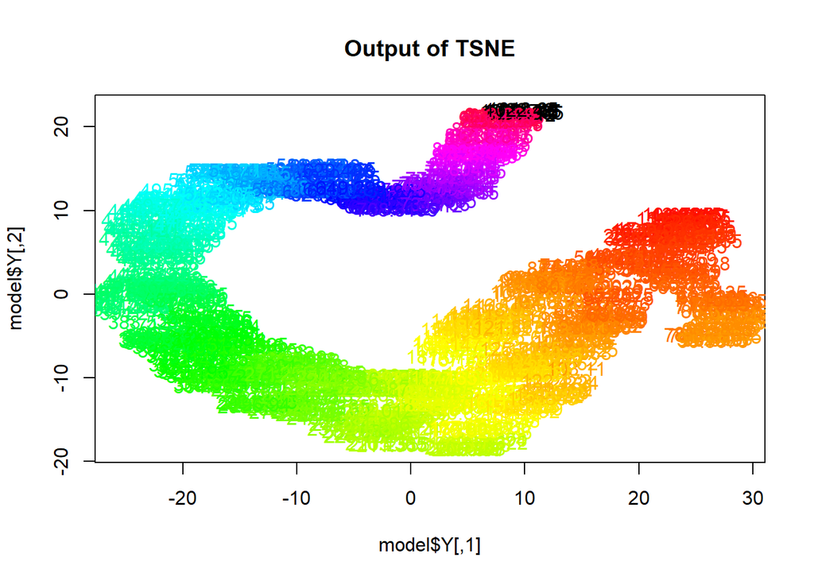

```r
plot(model$Y, t='n', main="Output of TSNE")
text(model$Y, labels=df$Total, col=colors[df$Total] )
```